# SQL for beginners

# 1 Before we start

We will need the following:

- [SQLite](https://www.sqlite.org/download.html).
- [DBeaver](https://dbeaver.io/download/).
- (Optional) Follow the steps [here](http://www.sqlitetutorial.net/download-install-sqlite/) to verify the installation.

DBeaver is just the IDE (development environment). It has the `Chinook` database that we will use. If you prefer to use another IDE, [download](https://github.com/lerocha/chinook-database) the `Chinook` database.

A map of the `Chinook` database is below:

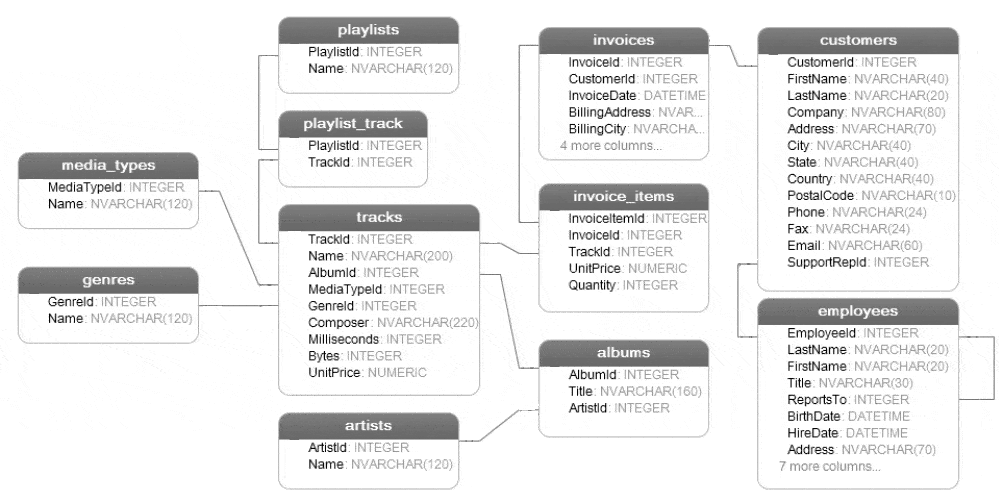

## 1.1 References

Two good resources for documentation and more exercises: - [SQLite tutorial](http://www.sqlitetutorial.net/). - [SQL Exercises Wikibook](https://en.wikibooks.org/wiki/SQL_Exercises).

Remember, practice makes perfection!

# 2 Basic SQL commands

## 2.1 SELECT

`SELECT` allows us to choose data from one or many tables:

`sql SELECT * FROM Artist LIMIT 10;`

For large production tables, it is good idea to use `LIMIT` to restrict the number of rows, specially if we only want to quickly look at the data.

You can select specific columns of a table:

```sql
SELECT Name, Milliseconds, Bytes from Track;
```

**Tip:** Avoid using the asterisk whenever possible in real life!

You can comment your queries with `/* comment */`:

```sql
SELECT City, Country FROM Customer; /* Where are our customers from? */
```

## 2.2 DISTINCT

This simply chooses distinct values.

```sql
SELECT DISTINCT Country FROM Customer; /* How many different countries?*/
```

## 2.3 ORDER BY

Ranks in ascending order (or alphabetically):

```sql
SELECT DISTINCT City, Country
FROM Customer ORDER BY Country;
```

You can override this with `DESC`

```sql
SELECT Name, Milliseconds, Bytes
FROM Track
ORDER BY Milliseconds DESC;
```

## 2.4 WHERE

`WHERE` filters by rows, if they fulfill a condition.

```sql
/* All the tracks from a given album? */
SELECT Name, Milliseconds, Bytes, AlbumId
FROM Track
WHERE AlbumId = 1;
```

It can do more complicated things, for instance:

- Filter from a list of values:

```sql
SELECT Name, Milliseconds, Bytes, AlbumId
FROM Track
WHERE AlbumId IN (1,2,3);
```

- Filter via several criteria:

  ```sql
  SELECT Name, Milliseconds, Bytes, AlbumId
  FROM Track
  WHERE AlbumId = 1 AND Milliseconds > 250000;
  ```

- Filter with some basic pattern matching. Run and compare each of the statements below separately!

```sql
SELECT Name FROM Track WHERE Name LIKE 'Samba%';
SELECT Name FROM Track WHERE Name LIKE 'Samba';
SELECT Name FROM Track WHERE Name LIKE '%Samba';

SELECT Name FROM Track WHERE Name LIKE '%B_ck%';
SELECT Name FROM Track WHERE Name LIKE '%B__ck%';


SELECT Name
FROM Track
WHERE Name GLOB '*[0-9]*';

SELECT Name
FROM Track
WHERE Name GLOB '*[^0-9]*';
```

- We can also filter by range, for instance, in time:

```sql
/* How many Invoices were there in 2009 and 2011? What are the respective total sales for each of those years? */
select COUNT(invoiceid), SUM(total)
from invoice
where invoicedate between datetime('2011-01-01 00:00:00') and datetime('2011-12-31 00:00:00');
```

## 2.5 GROUP BY

This command allows us to do basic calculations on groups.

```sql
/* How many tracks per album? */
SELECT AlbumId, COUNT(TrackId) as TracksPerAlbum
FROM Track
GROUP BY AlbumId
```

The query above tells SQLite to separate by groups per `AlbumId`. Since we will display only one value for each group, we need to specify what to do with the other column which is not part of the group, in this case, `TrackId`. We used the `COUNT` function. Other possibilities are:

- `AVG`
- `MAX`
- `MIN`
- `SUM`

You can combine all the statements above together, for instance:

```sql
/* How many tracks per album? In descending order */
SELECT AlbumId, COUNT(TrackId) as TracksPerAlbum
FROM Track
GROUP BY AlbumId
ORDER BY TracksPerAlbum DESC
```

## 2.6 HAVING

This command acts as a `WHERE` but for grouped tables, that are made on the fly. For example, let’s choose only albums with more than a certain number of tracks:

```sql
SELECT AlbumId, count(TrackId) as TracksPerAlbum
FROM Track
GROUP BY AlbumId
HAVING count(TrackId)>10;
```

## 2.7 CASE

Sometimes it is useful to modify a bit the data to present the results in a different way to, say, a business user. We use `CASE` to edit the data on the query. This does not modify the data stored in the database.

```sql
SELECT CustomerId,
     FirstName,
     LastName,
     Country,
    CASE
        WHEN Country = 'Czech Republic' THEN 'Domestic'
        WHEN Country = 'Austria' THEN 'Neighbor'
        ELSE 'Other'
    END CustomerSegment
FROM Customer
ORDER BY CustomerSegment
```

## 2.8 Exercises

Let’s get a bit of practice!

- Show only the Customers from Czech Republic.

  **Solution**

  ```sql
  select * from customer
  where country = 'Czech Republic';
  ```

- Show only the Employees who are Sales Agents.

  **Solution**

  ```sql
  select * from employee3
  where employee.title = 'Sales Support Agent';
  ```

- Provide a query that shows the # of invoices per country.

  **Solution**

  ```sql
  select billingcountry, count(billingcountry) as '# of invoices'
  from invoice
  group by billingcountry
  ```

- Show the total sales per country. Which country’s customers spent the most?

  **Solution**

  ```sql
  select billingcountry, sum(total) as 'TotalSales'
  from invoice
  group by billingcountry
  order by totalsales desc
  ```

- How many line items does Invoice ID 37 have?.

  **Solution**

  ```sql
  select count(i.invoicelineid)
  from invoiceline as i
  where i.invoiceid = 37
  ```

# 3 Joining tables

## 3.1 LEFT JOIN

```sql
SELECT Track.Name, Genre.Name
FROM Track
LEFT JOIN Genre
ON Track.GenreId = Genre.GenreId
```

```sql
/* Same query, using aliases*/
SELECT x.Name, y.Name
FROM Track x
LEFT JOIN Genre y
ON x.GenreId = y.GenreId
```

## 3.2 INNER JOIN

This is the deffault `JOIN` (so you do not need to explicitly type `INNER`).

This gives the intersection of both tables on the joining column (after `ON`). Example:

```sql
SELECT x.Name as TrackName, y.Title, y.AlbumId
FROM Track x
INNER JOIN
(
    SELECT Title, AlbumId
    FROM Album
    WHERE AlbumId IN (1,2,3)
) y
ON x.AlbumId = y.AlbumId
```

A somewhat convoluted example: For every employee, find the name of its manager.

```sql
SELECT m.FirstName || ' ' || m.LastName as 'Manager',
        e.FirstName || ' ' || e.LastName as 'Direct employee'
FROM Employee3 e
INNER JOIN Employee3 m
ON m.EmployeeId = e.ReportsTo;
```

Here we need to join the `Employee3` table with itself! (Do you see why?)

## 3.3 An equivalent syntax

If you find the previous syntax, you can write the queries in a slightly different way (for inner joins):

```sql
SELECT Track.Name, Album.Title
FROM Track, Album
WHERE Album.AlbumId = Track.AlbumId
ORDER BY Album.Title
```

This is equivalent to:

```sql
SELECT Track.Name, Album.Title
FROM Track
JOIN Album on Album.AlbumId = Track.AlbumId
ORDER BY Album.Title
```

## 3.4 Exercises

Let’s get a bit of practice!

- Provide a query showing the Invoices of customers who are from Czech Republic. The resultant table should show the customer’s full name, Invoice ID, Date of the invoice and billing country.

  **Solution**

  ```sql
  select c.firstname, c.lastname, i.invoiceid, i.invoicedate, i.billingcountry
  from customer as c, invoice as i
  where c.country = 'Czech Republic' and
  c.customerid = i.customerid;
  ```

- Provide a query showing the invoices of customers who are from Czech Republic.

  **Solution**

  ```sql
  select * from customer as c, invoice as i
  where c.country = 'Czech Republic' and
  c.customerid = i.customerid;
  ```

- Provide a query that shows the invoices associated with each sales agent. The resultant table should include the Sales Agent’s full name.

  **Solution**

  ```sql
  select e.firstname, e.lastname, i.invoiceid, i.customerid, i.invoicedate, i.billingaddress, i.billingcountry, i.billingpostalcode, i.total
  from customer as c, invoice as i
  on c.customerid = i.customerid
  join employee as e
  on e.employeeid = c.supportrepid
  order by e.employeeid;
  ```

- Provide a query that shows total sales made by each sales agent.

  **Solution**

  ```sql
  select e.*, count(i.invoiceid) as 'Total Number of Sales'
  from employee as e
  join customer as c on e.employeeid = c.supportrepid
  join invoice as i on i.customerid = c.customerid
  group by e.employeeid
  ```

- Provide a query that shows the most purchased track of 2013.

  **Solution**

  ```sql
  select *, count(t.trackid) as count
  from invoiceline as il
  join invoice as i on i.invoiceid = il.invoiceid
  join track as t on t.trackid = il.trackid
  where i.invoicedate between '2013-01-01' and '2013-12-31'
  group by t.trackid
  order by count desc
  ```

# 4 Creating and modifying the database

Let’s create our own database. Suppose we want a small database with two tables:

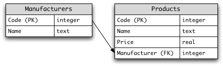

These tables will be related to each other by the manufacturer of each product.

In the `Manufacturers` table, this id should be a **primary key**: this is really just that, a unique identifier.

In the table `Products`, we create a column called `Manufacturer` that should keep that same id. To prevent adding manufacturers in the `Products` table that are not registered, we need to specify **constraints**.

Run the code below: what do we get?

```sql
CREATE TABLE Manufacturers (
    Code INTEGER PRIMARY KEY NOT NULL,
    Name TEXT NOT NULL
);

CREATE TABLE Products (
    Code INTEGER PRIMARY KEY NOT NULL,
    Name TEXT NOT NULL ,
    Price REAL NOT NULL ,
    Manufacturer INTEGER NOT NULL
        CONSTRAINT fk_Manufacturers_Code REFERENCES MANUFACTURERS(Code)
);
```

## 4.1 INSERT INTO

Let’s insert some data in our tables:

```sql
INSERT INTO Manufacturers(Code,Name) VALUES(1,'Sony');
INSERT INTO Manufacturers(Code,Name) VALUES(2,'Creative Labs');
INSERT INTO Manufacturers(Code,Name) VALUES(3,'Hewlett-Packard');
INSERT INTO Manufacturers(Code,Name) VALUES(4,'Iomega');
INSERT INTO Manufacturers(Code,Name) VALUES(5,'Fujitsu');
INSERT INTO Manufacturers(Code,Name) VALUES(6,'Winchester');

INSERT INTO Products(Code,Name,Price,Manufacturer) VALUES(1,'Hard drive',240,5);
INSERT INTO Products(Code,Name,Price,Manufacturer) VALUES(2,'Memory',120,6);
INSERT INTO Products(Code,Name,Price,Manufacturer) VALUES(3,'ZIP drive',150,4);
INSERT INTO Products(Code,Name,Price,Manufacturer) VALUES(4,'Floppy disk',5,6);
INSERT INTO Products(Code,Name,Price,Manufacturer) VALUES(5,'Monitor',240,1);
INSERT INTO Products(Code,Name,Price,Manufacturer) VALUES(6,'DVD drive',180,2);
INSERT INTO Products(Code,Name,Price,Manufacturer) VALUES(7,'CD drive',90,2);
INSERT INTO Products(Code,Name,Price,Manufacturer) VALUES(8,'Printer',270,3);
INSERT INTO Products(Code,Name,Price,Manufacturer) VALUES(9,'Toner cartridge',66,3);
INSERT INTO Products(Code,Name,Price,Manufacturer) VALUES(10,'DVD burner',180,2);
```

## 4.2 UPDATE

We can use this command to modify our data. For instance, if we want to change the name of product 8 to “Laser Printer”.

```sql
 UPDATE Products
   SET Name = 'Laser Printer'
   WHERE Code = 8;
```

or apply a discount:

```sql
UPDATE Products
   SET Price = Price - (Price * 0.1)
   WHERE Price >= 120;
```

## 4.3 DELETE

We can also delete some data rows:

```sql
DELETE FROM Products WHERE Code=8;
```

# 5 More complicated queries

We can use the `WITH` statement to create some “virtual table” that can help us make our queries more readable.

```sql
WITH Segments as (
    SELECT CustomerId, FirstName, LastName, Country,
        CASE
            WHEN Country = 'Czech Republic' THEN 'Domestic'
            WHEN Country = 'Austria' THEN 'Neighbor'
            ELSE 'Other'
        END CustomerSegment
FROM Customer
ORDER BY CustomerSegment
)
SELECT CustomerSegment, count(*)
FROM Segments
GROUP BY CustomerSegment
```

This particular example could be solved much easier (can you see how?), the point here is just to illustrate the syntax.

Your queries should be as readable as possible. Keeping a clear syntax helps, but also comments!

In the `Computer Store` database, select the name and price of the cheapest product.

```sql
 SELECT name,price
  FROM Products
  ORDER BY price ASC
  LIMIT 1
```

We can also use a **nested query** for that:

```sql
/* With a nested SELECT */
 SELECT Name, Price
   FROM Products
   WHERE Price = (SELECT MIN(Price) FROM Products);
```

# 6 Final exercises

## 6.1 Chinook

- Provide a query that shows the # of customers assigned to each sales agent.

  **Solution**

  ```sql
  select e.*, count(c.customerid) as 'TotalCustomers'
  from employee as e
  join customer as c on e.employeeid = c.supportrepid
  group by e.employeeid
  ```

- Provide a query that shows all the Tracks, but displays no IDs. The resultant table should include the Album name, Media type and Genre.

  **Solution**

  ```sql
  select t.name as 'track', a.title as 'album', g.name as 'genre', m.name as 'media type'
  from track as t
  join album as a on a.albumid = t.albumid
      join genre as g on g.genreid = t.genreid
      join mediatype as m on m.mediatypeid = t.mediatypeid
  ```

- Which sales agent made the most in sales in 2010?

  **Solution**

  ```sql
  select *, max(total) from
  (select e.*, sum(total) as 'Total'
  from employee as e
      join customer as c on e.employeeid = c.supportrepid
      join invoice as i on i.customerid = c.customerid
  where i.invoicedate between '2010-01-00' and '2010-12-31'
  group by e.employeeid)
  ```

## 6.2 Computer Store

- Apply a 10% discount to all products.

  **Solution**

  ```sql
  UPDATE Products
  SET Price = Price - (Price * 0.1);
  ```

- Add a new product: Loudspeakers, $70, manufacturer 2.

  **Solution**

  ```sql
  INSERT INTO Products( Code, Name , Price , Manufacturer)
  VALUES ( 11, 'Loudspeakers' , 70 , 2 );
  ```

- Select the names of manufacturer whose products have an average price larger than or equal to $150.

  **Solution**

  ```sql
   /* Without INNER JOIN */
  SELECT AVG(Price), Manufacturers.Name
  FROM Products, Manufacturers
  WHERE Products.Manufacturer = Manufacturers.Code
  GROUP BY Manufacturers.Name
  HAVING AVG(Price) >= 150;

  /* With INNER JOIN */
  SELECT AVG(Price), Manufacturers.Name
  FROM Products INNER JOIN Manufacturers
  ON Products.Manufacturer = Manufacturers.Code
  GROUP BY Manufacturers.Name
  HAVING AVG(Price) >= 150;
  ```

- Select the name of each manufacturer along with the name and price of its most expensive product.

  **Solution**

  ```sql
   /* With a nested SELECT and without INNER JOIN */
  SELECT A.Name, A.Price, F.Name
  FROM Products A, Manufacturers F
  WHERE A.Manufacturer = F.Code
      AND A.Price =
      (
      SELECT MAX(A.Price)
          FROM Products A
          WHERE A.Manufacturer = F.Code
      );

  /* With a nested SELECT and an INNER JOIN */
  SELECT A.Name, A.Price, F.Name
  FROM Products A INNER JOIN Manufacturers F
  ON A.Manufacturer = F.Code
      AND A.Price =
      (
      SELECT MAX(A.Price)
          FROM Products A
          WHERE A.Manufacturer = F.Code
      );
  ```

Yet more practice? Look at the excellent [SQL Exercises wikibook](https://en.wikibooks.org/wiki/SQL_Exercises). We recommend `The Hospital` for a serious challenge!